# White Wine Data Investigation

Kening Ren

# White Wine Quality.

This tidy data set contains 4,898 white wines with 11 variables on quantifying the chemical properties of each wine. At least 3 wine experts rated the quality of each wine, providing a rating between 0 (very bad) and 10 (very excellent).

# Target

Answer the following question: Which chemical properties influence the quality of white wines?

# Variables

## Input variables (based on physicochemical tests):

- fixed acidity (tartaric acid - g/dm^3 or g/L): most acids involved with wine or fixed or nonvolatile (do not evaporate readily)
- volatile acidity (acetic acid - g/dm^3 or g/L): the amount of acetic acid in wine, which at too high of levels can lead to an unpleasant, vinegar taste
- citric acid (g/dm^3 or g/L): found in small quantities, citric acid can add ‘freshness’ and flavor to wines
- residual sugar (g/dm^3 or g/L): the amount of sugar remaining after fermentation stops, it’s rare to find wines with less than 1 gram/liter and wines with greater than 45 grams/liter are considered sweet
- chlorides (sodium chloride - g/dm^3 or g/L): the amount of salt in the wine
- free sulfur dioxide (mg/dm^3 or mg/L): the free form of SO2 exists in equilibrium between molecular SO2 (as a dissolved gas) and bisulfite ion; it prevents microbial growth and the oxidation of wine
- total sulfur dioxide (mg/dm^3 or mg/L): amount of free and bound forms of S02; in low concentrations, SO2 is mostly undetectable in wine, but at free SO2 concentrations over 50 ppm, SO2 becomes evident in the nose and taste of wine
- density (g/cm^3 or kg/L): the density of water is close to that of water depending on the percent alcohol and sugar content
- pH: describes how acidic or basic a wine is on a scale from 0 (very acidic) to 14 (very basic); most wines are between 3-4 on the pH scale
- sulphates (potassium sulphate - g/dm^3 or g/L): a wine additive which can contribute to sulfur dioxide gas (S02) levels, which acts as an antimicrobial and antioxidant
- alcohol (% by volume): the percent alcohol content of the wine

## Output variable (based on sensory data):

- quality (score between 0 and 10): the output is based on sensory data (median of at least 3 evaluations made by wine experts). Each expert graded the wine quality between 0 (very bad) and 10 (very excellent).

# Univariate Plots Section

## Quality study

Here we need to look at the data.

```
## [1] 4898   13
```

```
##  [1] "X"                    "fixed.acidity"        "volatile.acidity"
##  [4] "citric.acid"          "residual.sugar"       "chlorides"
##  [7] "free.sulfur.dioxide"  "total.sulfur.dioxide" "density"
## [10] "pH"                   "sulphates"            "alcohol"
## [13] "quality"
```

```
##   X fixed.acidity volatile.acidity citric.acid residual.sugar chlorides
## 1 1           7.0             0.27        0.36           20.7     0.045
## 2 2           6.3             0.30        0.34            1.6     0.049
## 3 3           8.1             0.28        0.40            6.9     0.050
## 4 4           7.2             0.23        0.32            8.5     0.058
## 5 5           7.2             0.23        0.32            8.5     0.058
## 6 6           8.1             0.28        0.40            6.9     0.050
##   free.sulfur.dioxide total.sulfur.dioxide density   pH sulphates alcohol
## 1                  45                  170  1.0010 3.00      0.45     8.8
## 2                  14                  132  0.9940 3.30      0.49     9.5
## 3                  30                   97  0.9951 3.26      0.44    10.1
## 4                  47                  186  0.9956 3.19      0.40     9.9
## 5                  47                  186  0.9956 3.19      0.40     9.9
## 6                  30                   97  0.9951 3.26      0.44    10.1
##   quality
## 1       6
## 2       6
## 3       6
## 4       6
## 5       6
## 6       6
```

```
##        X        fixed.acidity    volatile.acidity  citric.acid
##  Min.   :   1   Min.   : 3.800   Min.   :0.0800   Min.   :0.0000
##  1st Qu.:1225   1st Qu.: 6.300   1st Qu.:0.2100   1st Qu.:0.2700
##  Median :2450   Median : 6.800   Median :0.2600   Median :0.3200
##  Mean   :2450   Mean   : 6.855   Mean   :0.2782   Mean   :0.3342
##  3rd Qu.:3674   3rd Qu.: 7.300   3rd Qu.:0.3200   3rd Qu.:0.3900
##  Max.   :4898   Max.   :14.200   Max.   :1.1000   Max.   :1.6600
##  residual.sugar     chlorides       free.sulfur.dioxide
##  Min.   : 0.600   Min.   :0.00900   Min.   :  2.00
##  1st Qu.: 1.700   1st Qu.:0.03600   1st Qu.: 23.00
##  Median : 5.200   Median :0.04300   Median : 34.00
##  Mean   : 6.391   Mean   :0.04577   Mean   : 35.31
##  3rd Qu.: 9.900   3rd Qu.:0.05000   3rd Qu.: 46.00
##  Max.   :65.800   Max.   :0.34600   Max.   :289.00
##  total.sulfur.dioxide    density             pH          sulphates
##  Min.   :  9.0        Min.   :0.9871   Min.   :2.720   Min.   :0.2200
##  1st Qu.:108.0        1st Qu.:0.9917   1st Qu.:3.090   1st Qu.:0.4100
##  Median :134.0        Median :0.9937   Median :3.180   Median :0.4700
##  Mean   :138.4        Mean   :0.9940   Mean   :3.188   Mean   :0.4898
##  3rd Qu.:167.0        3rd Qu.:0.9961   3rd Qu.:3.280   3rd Qu.:0.5500
##  Max.   :440.0        Max.   :1.0390   Max.   :3.820   Max.   :1.0800
##     alcohol         quality
##  Min.   : 8.00   Min.   :3.000
##  1st Qu.: 9.50   1st Qu.:5.000
##  Median :10.40   Median :6.000
##  Mean   :10.51   Mean   :5.878
##  3rd Qu.:11.40   3rd Qu.:6.000
##  Max.   :14.20   Max.   :9.000
```

Check Quality data.

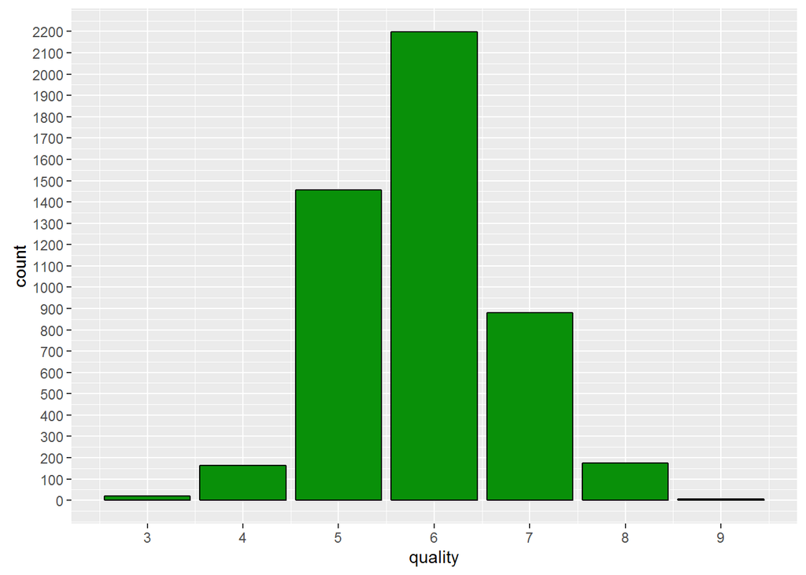

```
##    Min. 1st Qu.  Median    Mean 3rd Qu.    Max.
##   3.000   5.000   6.000   5.878   6.000   9.000
```

## The distribution of all the input variables:

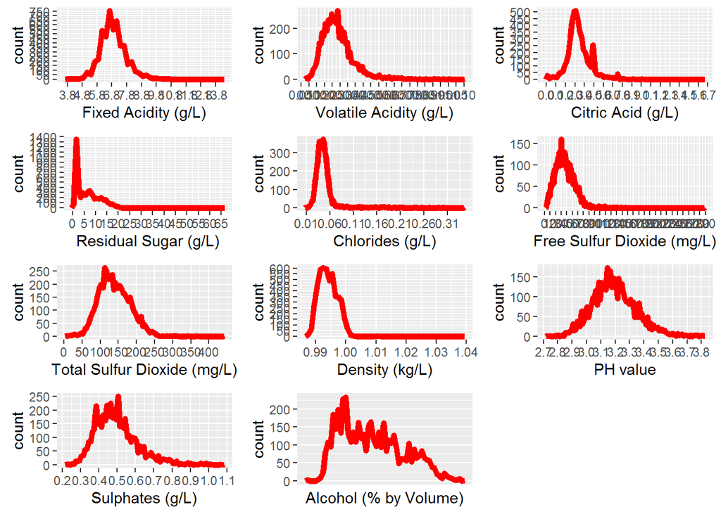

Most of the input variables are like in the normal distribution. But residual.sugar is positively skewed.

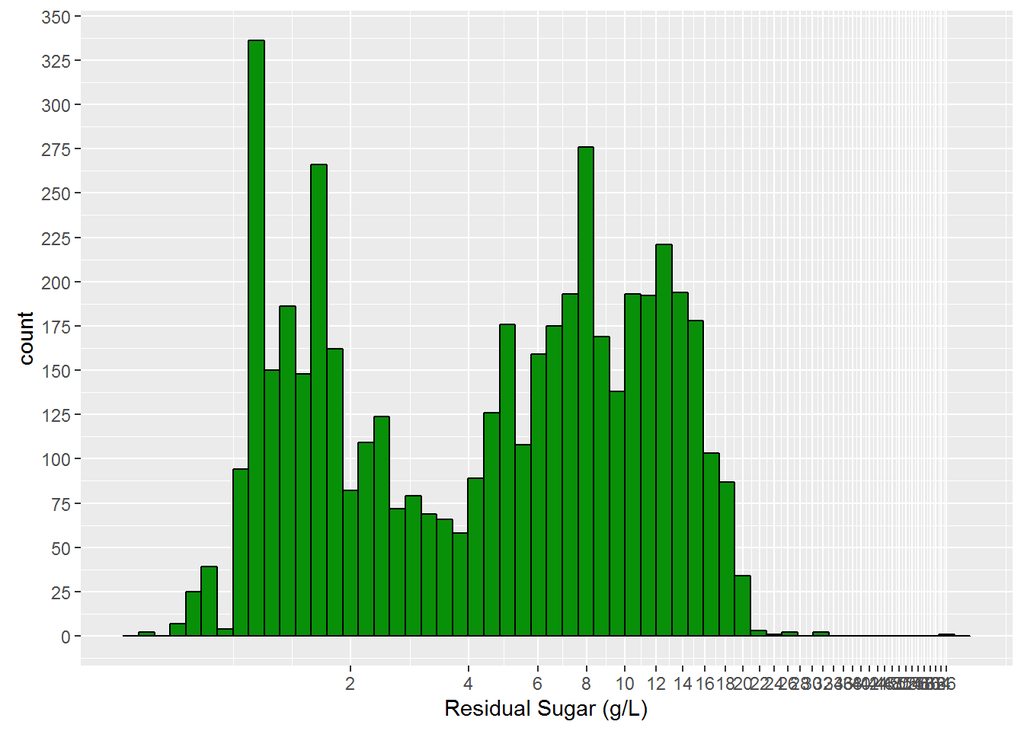

```
##    Min. 1st Qu.  Median    Mean 3rd Qu.    Max.
##   0.600   1.700   5.200   6.391   9.900  65.800
```

In fact, residual.sugar is bimodal distribution. One peak is at residual.sugar = 1.5g/L. The other one is at residual.sugar = 8g/L. Residual sugar brings the sweetness of the wine. The sweetness is also enhanced by alcohol in the wine. I wonder why not many wines have the residual sugar at about 4g/L. Maybe it is because in this dataset, the wines come from certain geographical areas and/or certain type of grapes, which produce the wines rarely having about 4g/L residual sugar.

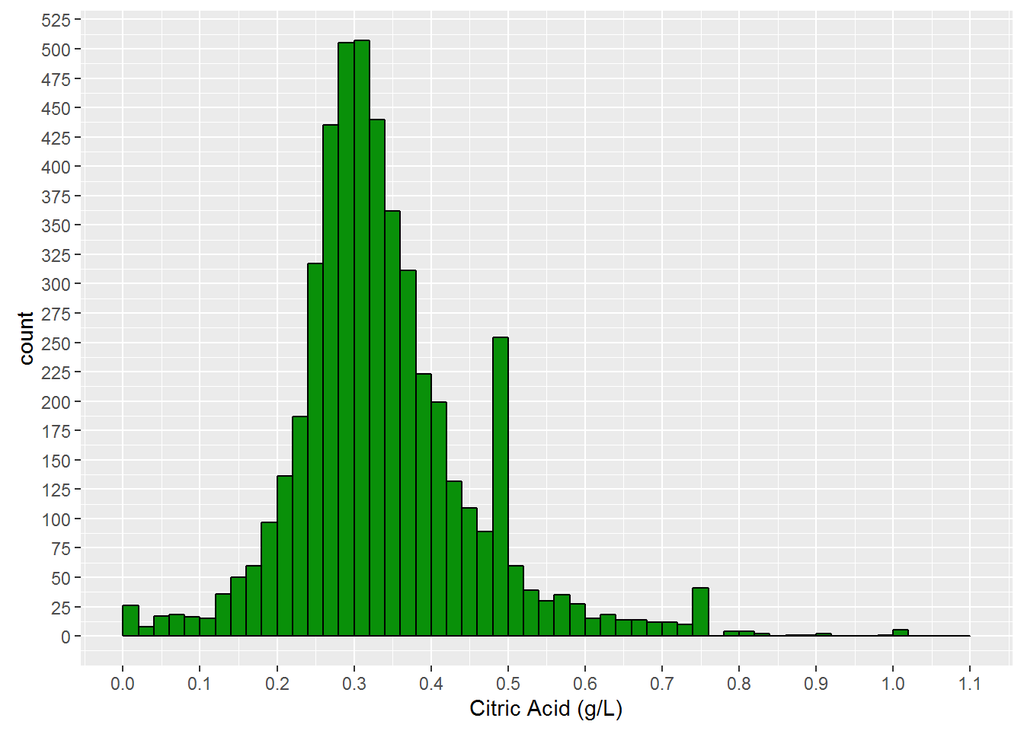

```
##    Min. 1st Qu.  Median    Mean 3rd Qu.    Max.
##  0.0000  0.2700  0.3200  0.3342  0.3900  1.6600
```

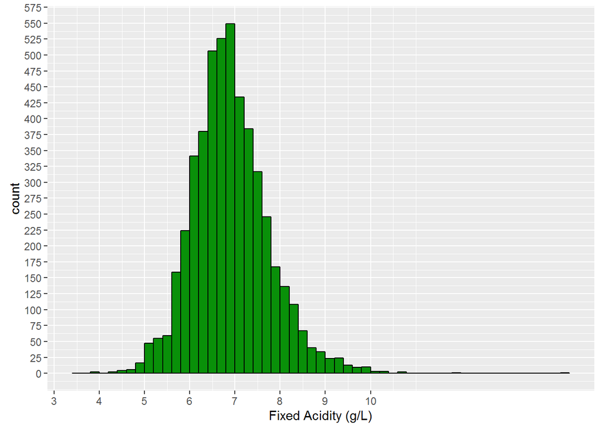

```
##    Min. 1st Qu.  Median    Mean 3rd Qu.    Max.
##   3.800   6.300   6.800   6.855   7.300  14.200
```

50% of the wines have Fixed Acidity from 6.3 to 7.3g/L. Median is 6.8g/L. Fixed Acidity imparts the sourness of the wine. Wines lacking in acid are “flat”. Acidity affects the taste and pH value. Later I will check whether acidity really affects pH value. I believe Citric acid is one kind of the fixed acidity. Later I will try to verify whether this is true mathematically.

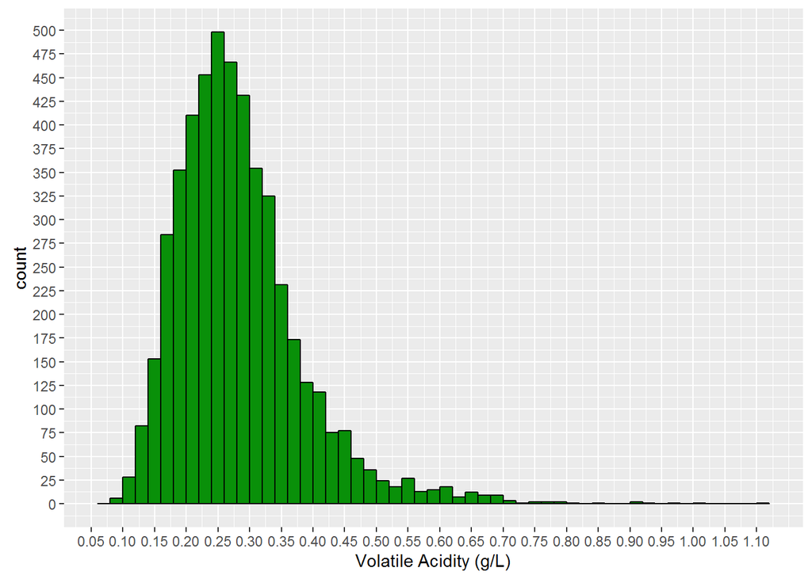

```
##    Min. 1st Qu.  Median    Mean 3rd Qu.    Max.
##  0.0800  0.2100  0.2600  0.2782  0.3200  1.1000
```

Volatile Acidity is a positively skewed normal distribution. Median value is 0.26. 50% of wines have Volatile Acidity between 0.21 and 0.32.

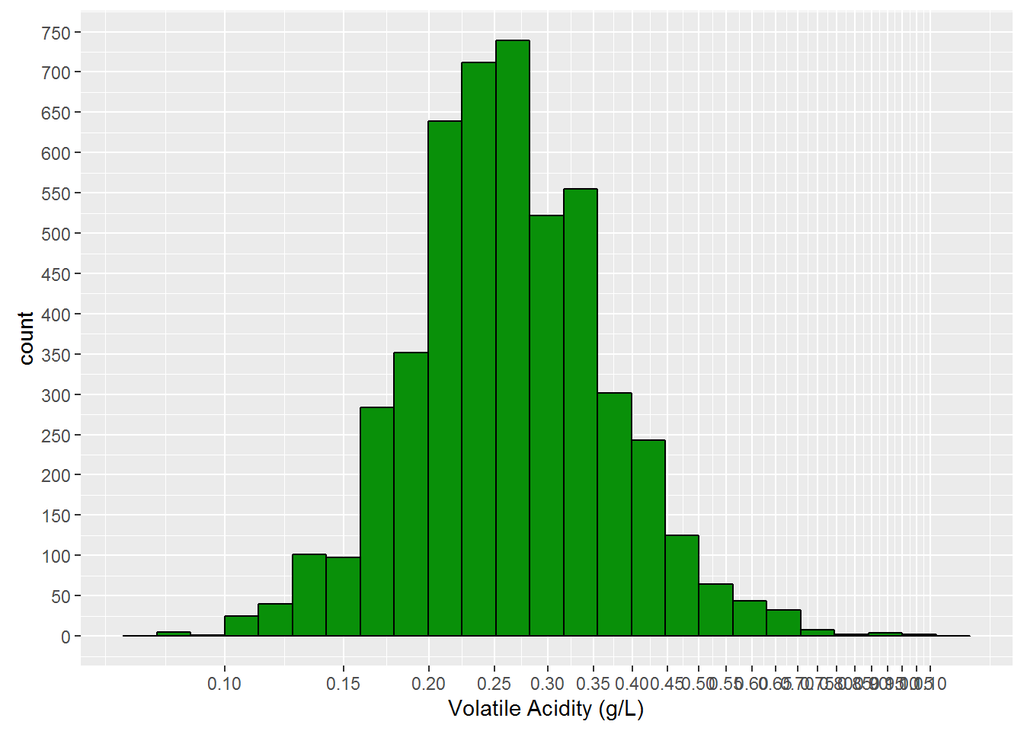

U.S. legal limit of Volatile acidity for the white wine is 1.1g/L (See http://waterhouse.ucdavis.edu/whats-in-wine/volatile-acidity[link](http://waterhouse.ucdavis.edu/whats-in-wine/volatile-acidity)) Here let us see how many wines exceed the US limit of Volatile acidity.

```
## [1] 0
```

Interesting. No wines exceed the limit. I guess only wines within the limit are allowed in markets. In wines, Volatile acidity should be as low as possible.

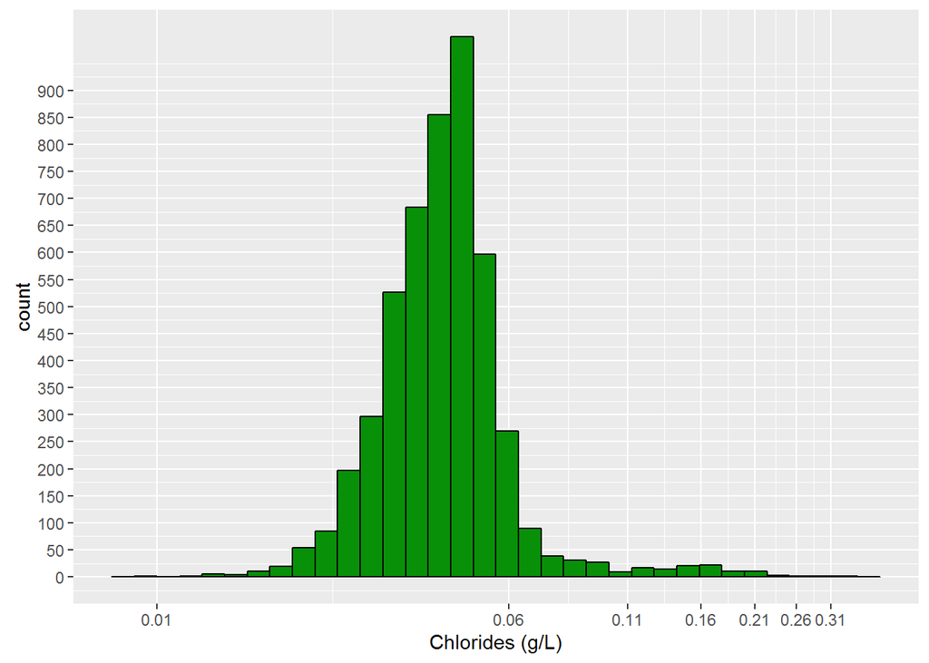

```
##    Min. 1st Qu.  Median    Mean 3rd Qu.    Max.
## 0.00900 0.03600 0.04300 0.04577 0.05000 0.34600
```

Median is 0.043g/L. 50% of wines have chlorides from 0.036g/L to 0.05g/L. It is salt in wines. The vine takes the salt from water and deposits into the grapes. It is said that in some cases high salt levels can soften the acidity in wines. So salt is added when acidity is high in wines. I would like to study whether this is true.

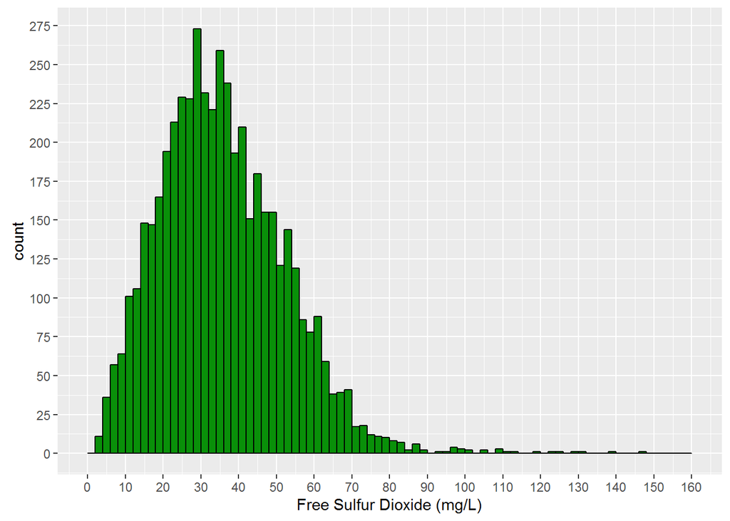

```
##    Min. 1st Qu.  Median    Mean 3rd Qu.    Max.
##    2.00   23.00   34.00   35.31   46.00  289.00
```

Sulfur dioxide is a fruit preservative widely used in wines. Free sulfur dioxide is the free form of SO2. In US, the law states that wines cannot contain more than 350mg/L. In this dataset, the median is 34mg/L. 50% of wines have from 23mg/L to 46mg/L. I wonder if Sulfur dioxide is affecting the quality of wines.

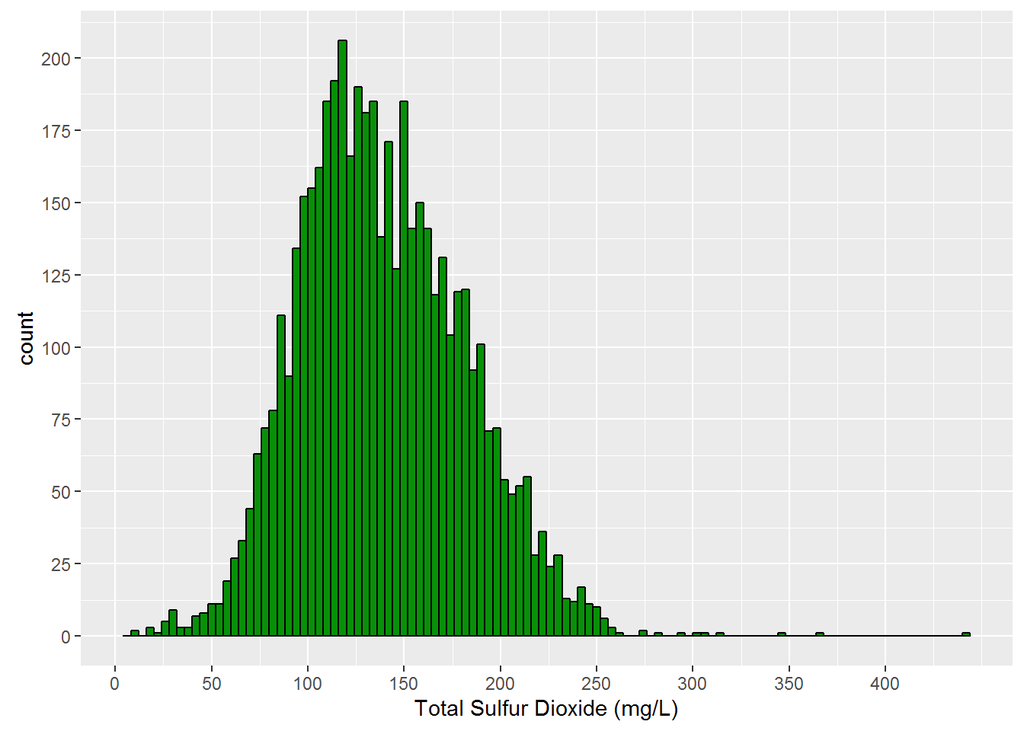

```
##    Min. 1st Qu.  Median    Mean 3rd Qu.    Max.
##     9.0   108.0   134.0   138.4   167.0   440.0
```

Total sulfur dioxide includes the free form and bound form of SO2. Too high of sulfur dioxide can be detected by human nose. And it affects the taste of wines. I would like to find out how it affects Quality of wines. The maximum sulfur dioxide is 440mg/L. It exceeds the US legal limit. Here I will check how many wines exceed the US limit.

```
## [1] 2
```

So two wines exceed the US limit.

Total Sulfur Dioxide are free and bound forms of S02. It includes Free Sulfur Dioxide and Bound Sulfur Dioxide. Here I am going to create a variable for the Bound Sulfur Dioxide. Study shows that the bound form of sulfur dioxide is Sulfates attached to sugars with some othercompounds.

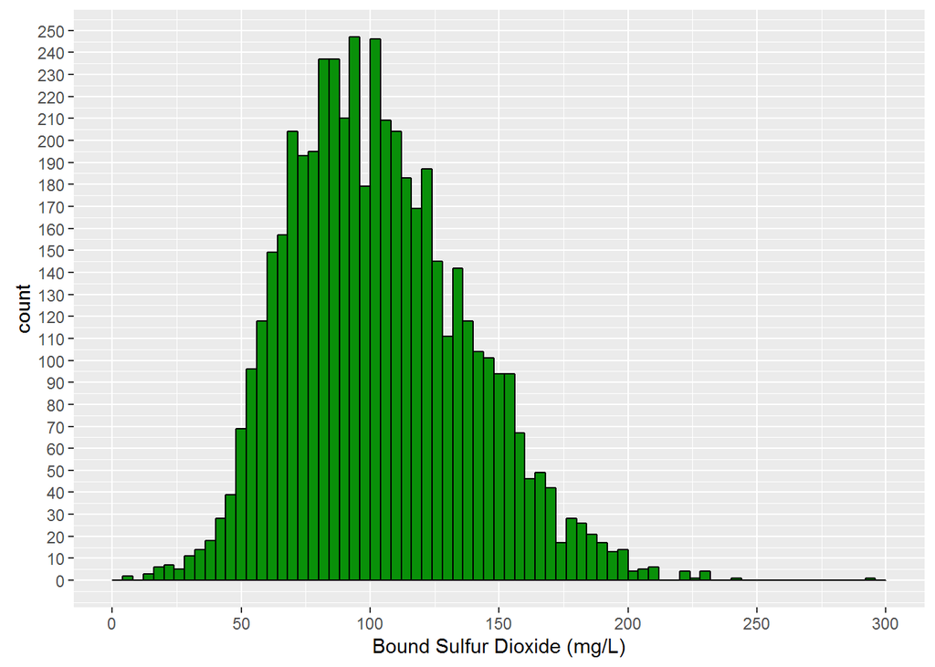

```
##    Min. 1st Qu.  Median    Mean 3rd Qu.    Max.
##     4.0    78.0   100.0   103.1   125.0   331.0
```

The median is 100mg/L. About 50% of wines have the Bound Sulfur Dioxide from 78mg/L to 125mg/L.

Acidity can be divided as Fixed Acidity and Volatile Acidity. I created a variable for the Total Acidity, which is the sum of Fixed Acidity and Volatile Acidity.

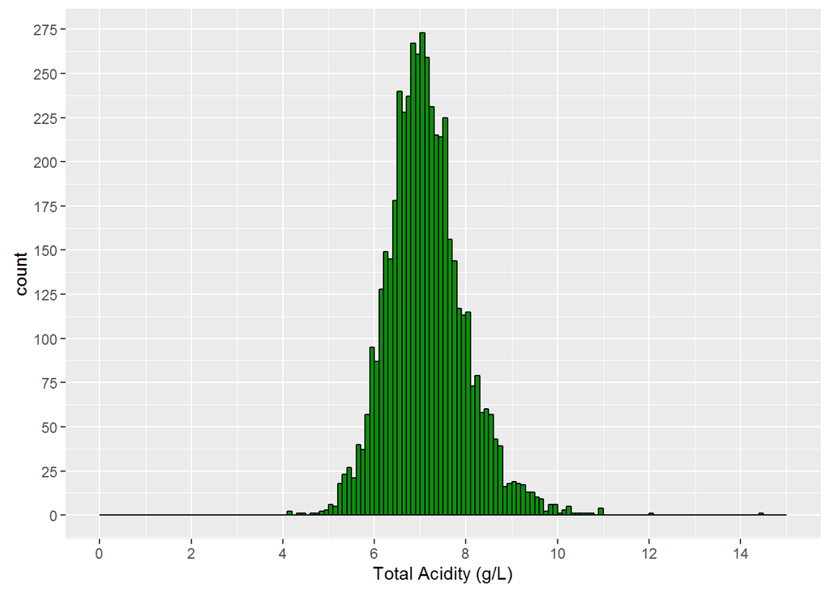

```
##    Min. 1st Qu.  Median    Mean 3rd Qu.    Max.
##   4.110   6.570   7.070   7.133   7.590  14.470
```

The median is 7.07 g/L. About 50% of wines have Total Acidity from 6.57g/L to 7.59g/L.

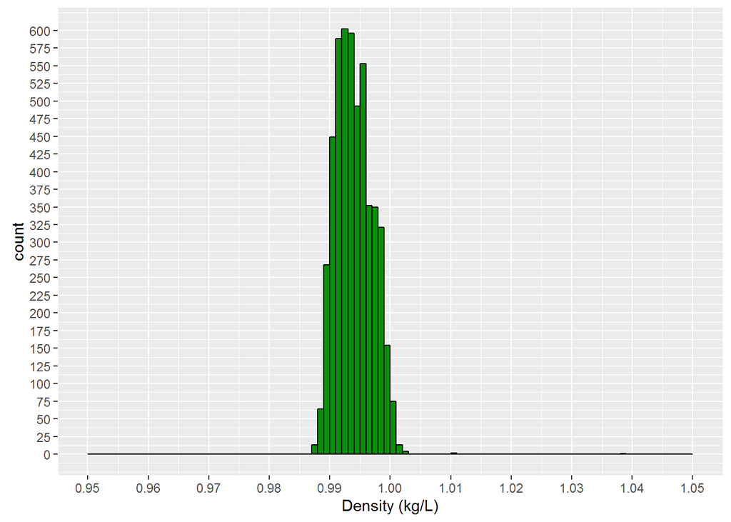

```
##    Min. 1st Qu.  Median    Mean 3rd Qu.    Max.
##  0.9871  0.9917  0.9937  0.9940  0.9961  1.0390
```

Apparently wine is mostly made of water. So the density of wine should be close to that of water 1Kg/L. However alcohol and sugar affect it. Alcohol has less density than water. The more alcohol the wine has the less density it has. Sugar is much heavier than water. The more sugar it has the heavier the wine is. However in wines, sugar is much less than alcohol, so wines tend to have less density than water. I would like to know how it is related to the quality of wines.

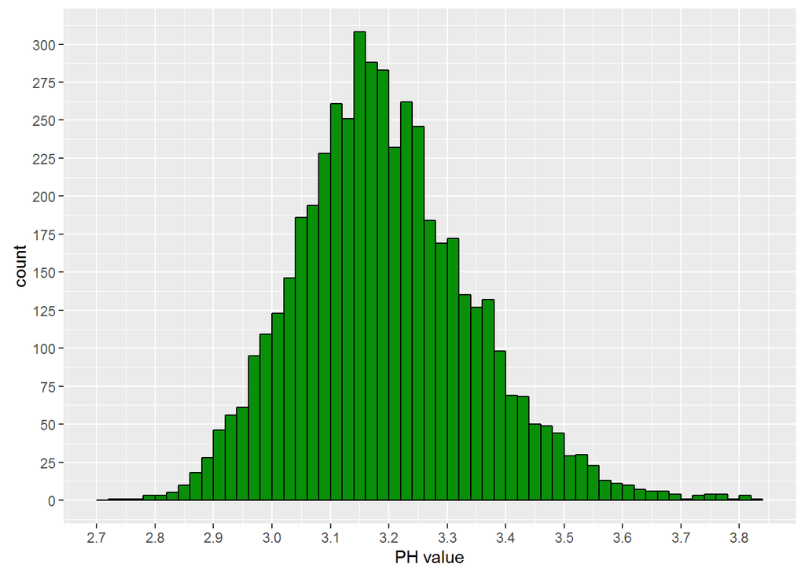

```
##    Min. 1st Qu.  Median    Mean 3rd Qu.    Max.
##   2.720   3.090   3.180   3.188   3.280   3.820
```

Winemakers use pH as a way to measure ripeness in relation to acidity. Low pH wines will taste tart and crisp, while higher pH wines are more susceptible to bacterial growth. In this dataset, median is 3.18. 50% of wines have pH value between 3.09 and 3.28. Apparently the pH value of a wine is affected by the acidity of the wine. So I think pH value affects the quality of the wine in the same way as acidity does. And I would like to know if this is true.

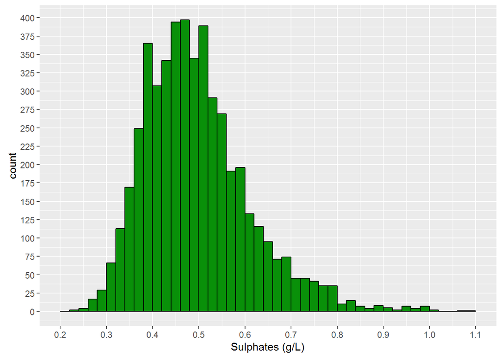

```
##    Min. 1st Qu.  Median    Mean 3rd Qu.    Max.
##  0.2200  0.4100  0.4700  0.4898  0.5500  1.0800
```

Potassium sulphate, which acts as an antimicrobial and antioxidant to wines. It contributes to the free sulfur dioxide and total sulfur dioxide. It may affect the quality of wines since it can be detected by human nose. I will check whether this is true.

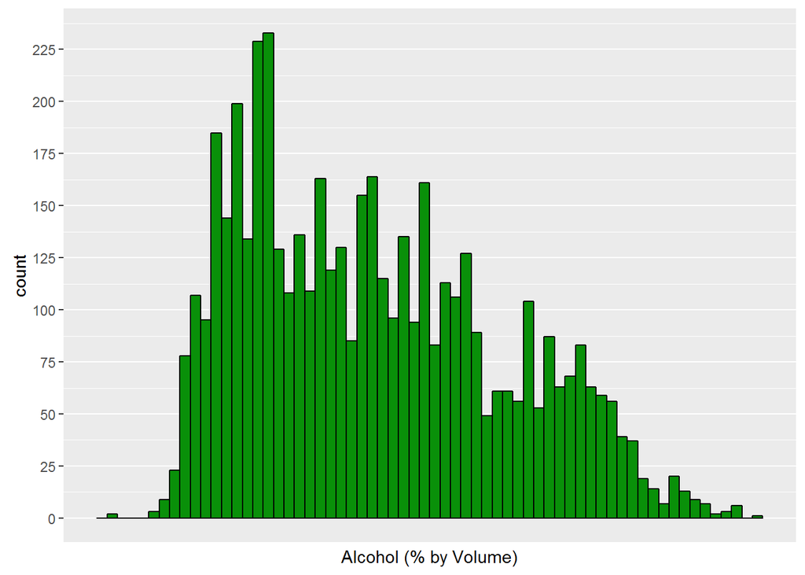

```
##    Min. 1st Qu.  Median    Mean 3rd Qu.    Max.
##    8.00    9.50   10.40   10.51   11.40   14.20
```

Alcohol is a very important chemical inside wine. I think it affects the taste and therefor the quality of wine. I will study how. In the dataset, the median value is 10.4%. 50% of wines have 9.5% to 11.4% alcohol.

# Univariate Analysis

## What is the structure of your dataset?

There are 4898 white wines in the dataset with 12 features (fixed acidity, volatile acidity, citric acid, residual sugar, chlorides, free sulfur dioxide, total sulfur dioxide, density, pH, sulphates, alcohol, and quality) Most of the features have the normal distribution. Only the residual sugar has a clear bimodal distribution.

## What is/are the main features of interest in your dataset?

The main feature in the dataset is Quality. I would like to find out how other features ( fixed acidity, volatile acidity, citric acid, residual sugar, chlorides, free sulfur dioxide, total sulfur dioxide, density, pH, sulphates, and alcohol ) are correlated to wine quality. And if possible, I want to figure out which features and/or some combination of these features can be used to build a predictive model to wine quality.

## What other features in the dataset do you think will help support your investigation into your feature(s) of interest?

Among all of the features, I think Density, Alcohol and Residual Sugar contribute most to the quality of wines after researching information on wine qualities.

## Did you create any new variables from existing variables in the dataset?

Yes. Total Sulfur Dioxide has free and bound forms of S02. It includes Free Sulfur Dioxide and Bound Sulfur Dioxide. I created a variable for the Bound Sulfur Dioxide.

Acidity can be divided as Fixed Acidity and Volatile Acidity. I created a variable, the Total Acidity, which combines Fixed Acidity and Volatile Acidity together.

## Of the features you investigated, were there any unusual distributions? Did you perform any operations on the data to tidy, adjust, or change the form of the data? If so, why did you do this?

Residual sugar is positively skewed. So I log-transformed its distribution. The resulted distribution of Residual sugar appears to be bimodal with the count peaking around 1.5g/L and again around 8g/L. It also shows that not many wines have the residual sugar at 4g/L.

# Bivariate Plots Section

The Pearson correlation between any features are calculated:

```
##                                 X fixed.acidity volatile.acidity
## X                     1.000000000   -0.25581431      0.002857966
## fixed.acidity        -0.255814305    1.00000000     -0.022697290
## volatile.acidity      0.002857966   -0.02269729      1.000000000
## citric.acid          -0.149899918    0.28918070     -0.149471811
## residual.sugar        0.006623775    0.08902070      0.064286060
## chlorides            -0.045645192    0.02308564      0.070511571
## free.sulfur.dioxide  -0.011928911   -0.04939586     -0.097011939
## total.sulfur.dioxide -0.161979037    0.09106976      0.089260504
## density              -0.185976097    0.26533101      0.027113845
## pH                   -0.115774132   -0.42585829     -0.031915368
## sulphates             0.009807759   -0.01714299     -0.035728147
## alcohol               0.213656245   -0.12088112      0.067717943
## quality               0.035763247   -0.11366283     -0.194722969
## bound.sulfur.dioxide -0.192413361    0.13566071      0.156769227
## total.acidity        -0.254350594    0.99290766      0.096321153
##                       citric.acid residual.sugar   chlorides
## X                    -0.149899918    0.006623775 -0.04564519
## fixed.acidity         0.289180698    0.089020701  0.02308564
## volatile.acidity     -0.149471811    0.064286060  0.07051157
## citric.acid           1.000000000    0.094211624  0.11436445
## residual.sugar        0.094211624    1.000000000  0.08868454
## chlorides             0.114364448    0.088684536  1.00000000
## free.sulfur.dioxide   0.094077221    0.299098354  0.10139235
## total.sulfur.dioxide  0.121130798    0.401439311  0.19891030
## density               0.149502571    0.838966455  0.25721132
## pH                   -0.163748211   -0.194133454 -0.09043946
## sulphates             0.062330940   -0.026664366  0.01676288
## alcohol              -0.075728730   -0.450631222 -0.36018871
## quality              -0.009209091   -0.097576829 -0.20993441
## bound.sulfur.dioxide  0.102179337    0.344844495  0.19379550
## total.acidity         0.270135269    0.096274432  0.03136937
##                      free.sulfur.dioxide total.sulfur.dioxide     density
## X                          -0.0119289106         -0.161979037 -0.18597610
## fixed.acidity              -0.0493958591          0.091069756  0.26533101
## volatile.acidity           -0.0970119393          0.089260504  0.02711385
## citric.acid                 0.0940772210          0.121130798  0.14950257
## residual.sugar              0.2990983537          0.401439311  0.83896645
## chlorides                   0.1013923521          0.198910300  0.25721132
## free.sulfur.dioxide         1.0000000000          0.615500965  0.29421041
```

[output cut: 25 more lines]

```
## X                            -0.192413361   -0.25435059
## fixed.acidity                 0.135660713    0.99290766
## volatile.acidity              0.156769227    0.09632115
## citric.acid                   0.102179337    0.27013527
## residual.sugar                0.344844495    0.09627443
## chlorides                     0.193795498    0.03136937
## free.sulfur.dioxide           0.263537284   -0.06071539
## total.sulfur.dioxide          0.922482350    0.10128441
## density                       0.504446902    0.26738970
## pH                            0.003143387   -0.42778274
## sulphates                     0.135693943   -0.02131642
## alcohol                      -0.426923036   -0.11229714
## quality                      -0.217867760   -0.13631969
## bound.sulfur.dioxide          1.000000000    0.15370752
## total.acidity                 0.153707525    1.00000000
```

In order to clearly show the relationship between different features, here I split the features into several different plots. Since this study is to find out how Quality is related to other features, in each plot, Quality is plotted.

We can see the correlation coefficients between Quality and other features in the plots below. In order to evaluate these correlation coefficients, here I use the popular guidelines:

- 0<|r|<0.3: Weak correlation
- 0.3<|r|<0.7: moderate correlation
- |r|>0.7: strong correlation

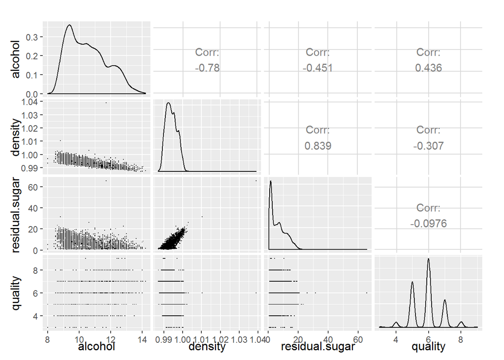

In the plot above, we can see Density and Alcohol have the moderate correlation with Quality. Residual Sugar has a weak correlation instread. Among these features, Density has very strong correlation with Alcohol and Residual Sugar. The reason of this strong correlation is studied later.

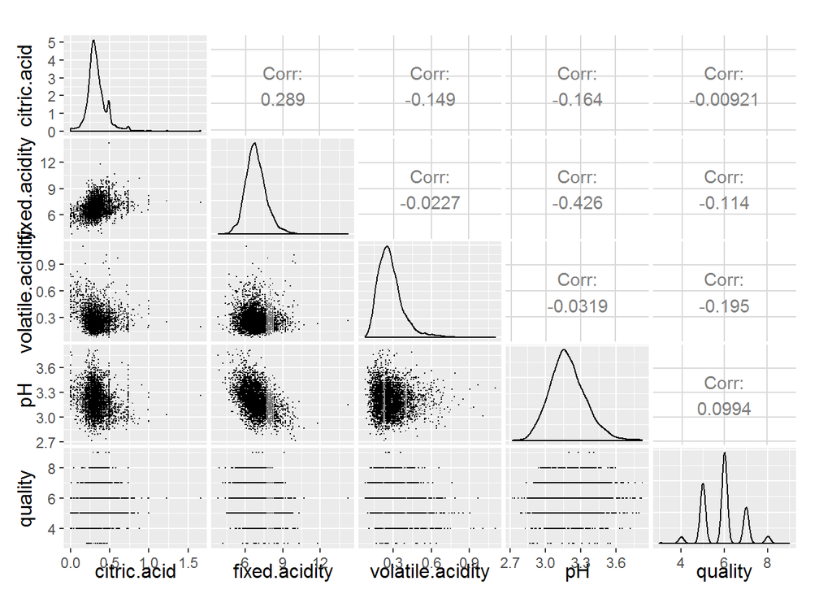

In the plot above, Citric Acid, Fixed Acidity, Volatile Acidity, and pH all have weak correlation with Quality. However among these features, pH has a moderate correlation with Fixed Acidity.

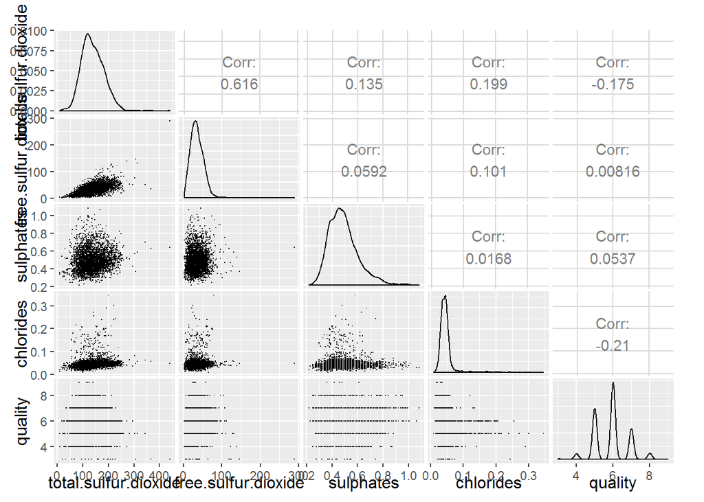

In the plot above, Total Sulfur Dioxide, Free Sulfur Dioxide, Sulphates, and Chlorides all have the weak correlation with Quality. However Free Sulfur Dioxide has a nearly strong correlaton with Total Sulfur Dioxide.

I find the features which have moderate correlation with Quality. Here they are:

```
##
##  Pearson's product-moment correlation
##
## data:  wine$quality and wine$alcohol
## t = 33.858, df = 4896, p-value < 2.2e-16
## alternative hypothesis: true correlation is not equal to 0
## 95 percent confidence interval:
##  0.4126015 0.4579941
## sample estimates:
##       cor
## 0.4355747
```

So Alcohol is positively correlated to Quality. The higher Alcohol the better quality.

```
##
##  Pearson's product-moment correlation
##
## data:  wine$quality and wine$density
## t = -22.581, df = 4896, p-value < 2.2e-16
## alternative hypothesis: true correlation is not equal to 0
## 95 percent confidence interval:
##  -0.3322718 -0.2815385
## sample estimates:
##        cor
## -0.3071233
```

So Density is negatively correlated to Quality. The higher Density the lower quality.

I want to look closer at the boxplot involving Quality and Density, as well as Alcohol.

Before plotting, I need to create a function wine_quality_boxplot(). This function will draw a boxplot to show the relationship between Quality of wines and any other feature.

Before drawing the boxplot, I need to group the dataset using Quality.

Here is the boxplot of Alcohol vs Quality.

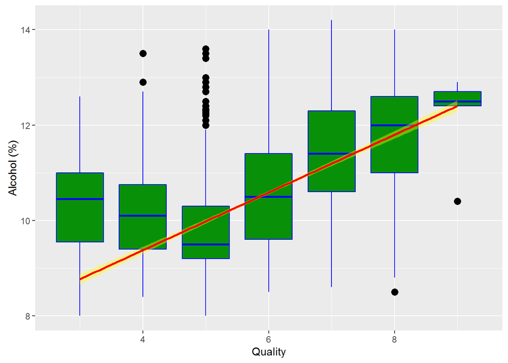

The line modeling shows that wines with high Alcohol level tend to have high Quality. To further study this, I will draw a different plot. In order to draw this plot, I need to convert Alcohol to a Categorical variable.

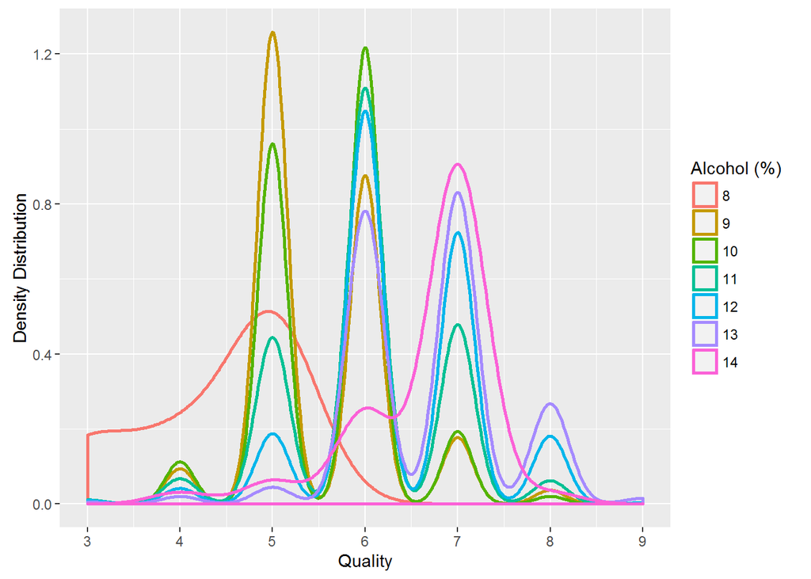

Here is the boxplot of Density vs Quality.

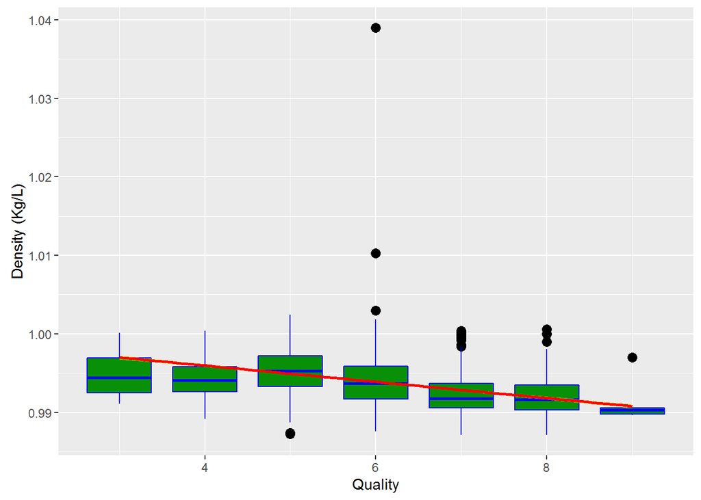

Apparently there exist some outliers which are affecting the line regression. I need to remove these outliers.

Here I create a function remove_outliers() to remove outliers on a feature from the dataset. It uses the popular algorithm of detecting outliers: data not inside the range [Q1 - 1.5*IQR, Q3 + 1.5*IQR].

This is the statistics of Density before removing the outliers.

```
##    Min. 1st Qu.  Median    Mean 3rd Qu.    Max.
##  0.9871  0.9917  0.9937  0.9940  0.9961  1.0390
```

This is the statistics of Density after removing the outliers,

```
##    Min. 1st Qu.  Median    Mean 3rd Qu.    Max.
##  0.9871  0.9917  0.9937  0.9940  0.9961  1.0020
```

It confirms that the function remove_outliers() is working.

Outliers are removed and redraw the plot.

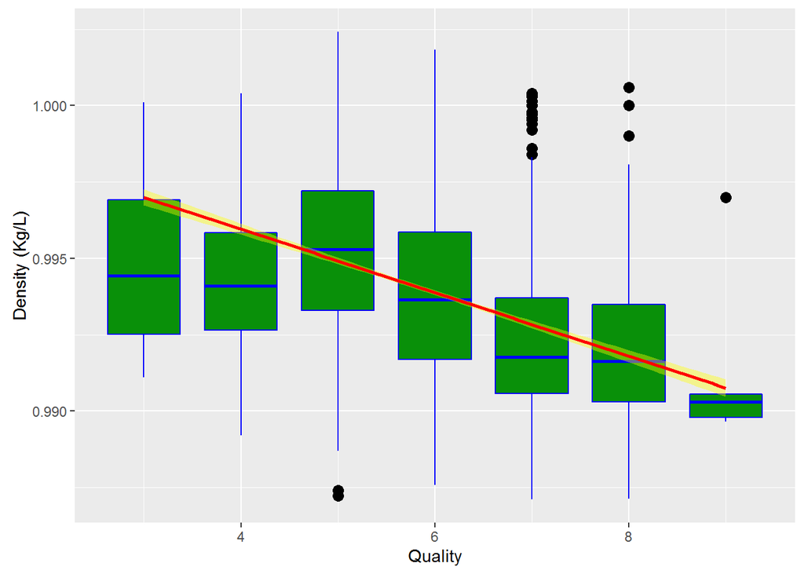

The line modeling shows that wines with high Density level tend to have low Quality. To further study this, I am going to draw a density distribution plot. And I need to convert Density to a categorical variable.

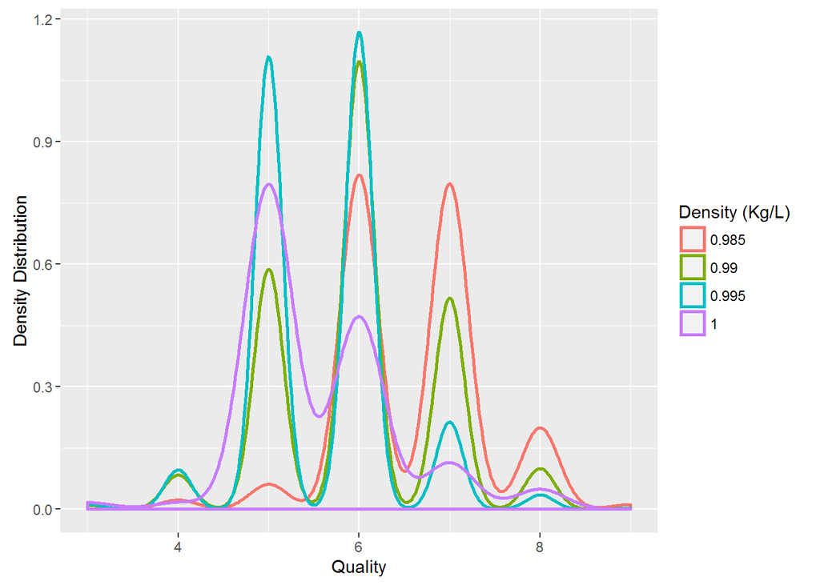

Why does high Density bring down the quality of wines? I think the density of wine is mainly affected by alcohol and the residual sugar inside wines. Here we already verify that high alcohol level does improve the quality of wines. The residual sugar increases the density of wine since it is much heavier than alcohol. So I think the residual sugar brings down the quality of wine.

I will verify this conclusion by studying the correlation between the residual sugar and the quality of wines.

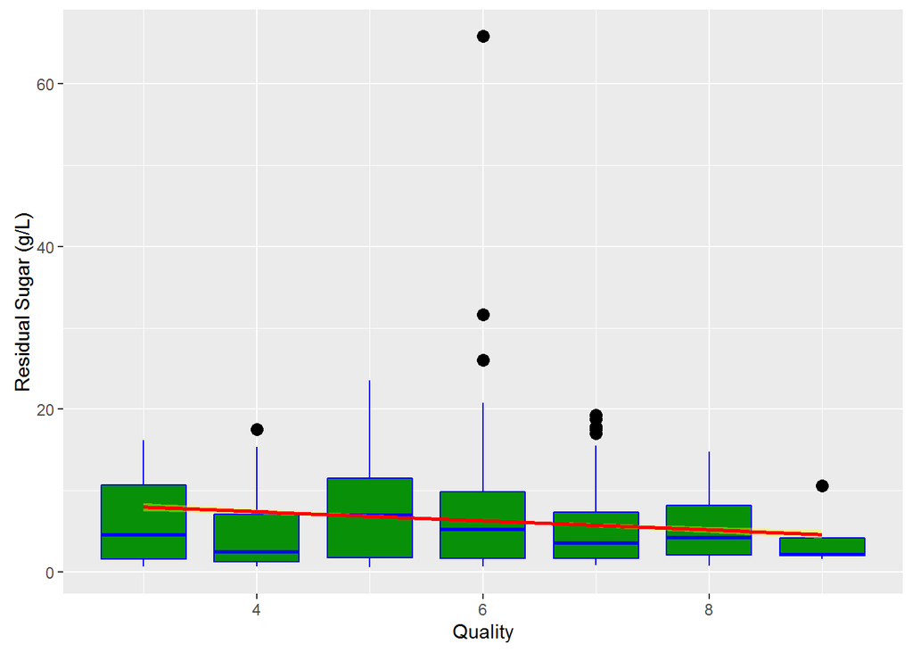

We see that there are outliers of Residual sugar. Let me remove them.

Let us draw the plot.

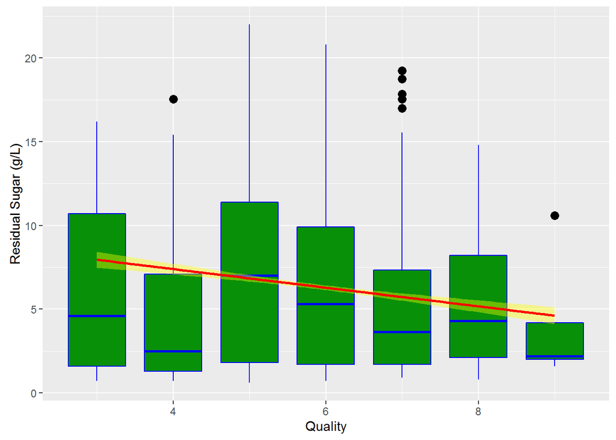

So we can see that the residual sugar does bring down the quality of wines a bit. To further study it, I am going to draw the density distribution plot. And I need to convert Residual Sugar to a categorical variable.

Before doing it, remove the outliers.

Convert it to be Categorical.

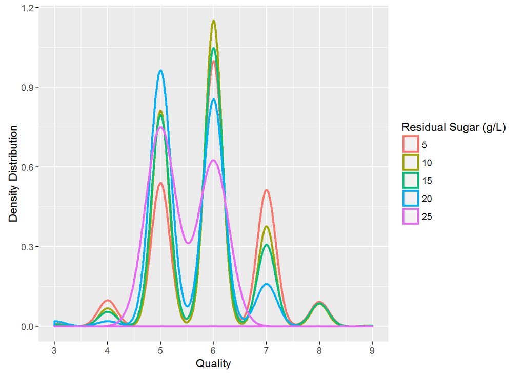

In this plot, we can see when Residual Sugar is 25g/L, it happens more often when Quality is low, such as Quality = 5 and 6. So does when Residual Sugar is 20g/L. When Residual Sugar is only 5g/L, it happens a lot in Quality = 7. This Density distribution plot explains the trend that low Residual Sugar level occurs more often at high Quality while wines with high level of Residual Sugar tend to occur more often at low Quality.

Next, I need to study whether the free.sulfur.dioxide affects the quality of wine.

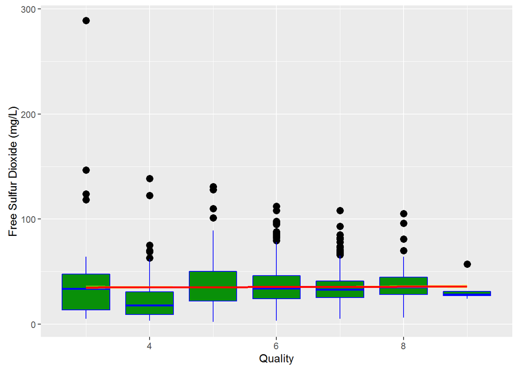

I am afraid that the outliers of Free Sulfur Dioxide are affecting the accuracy. I need to remove these outliers.

Redraw the plot.

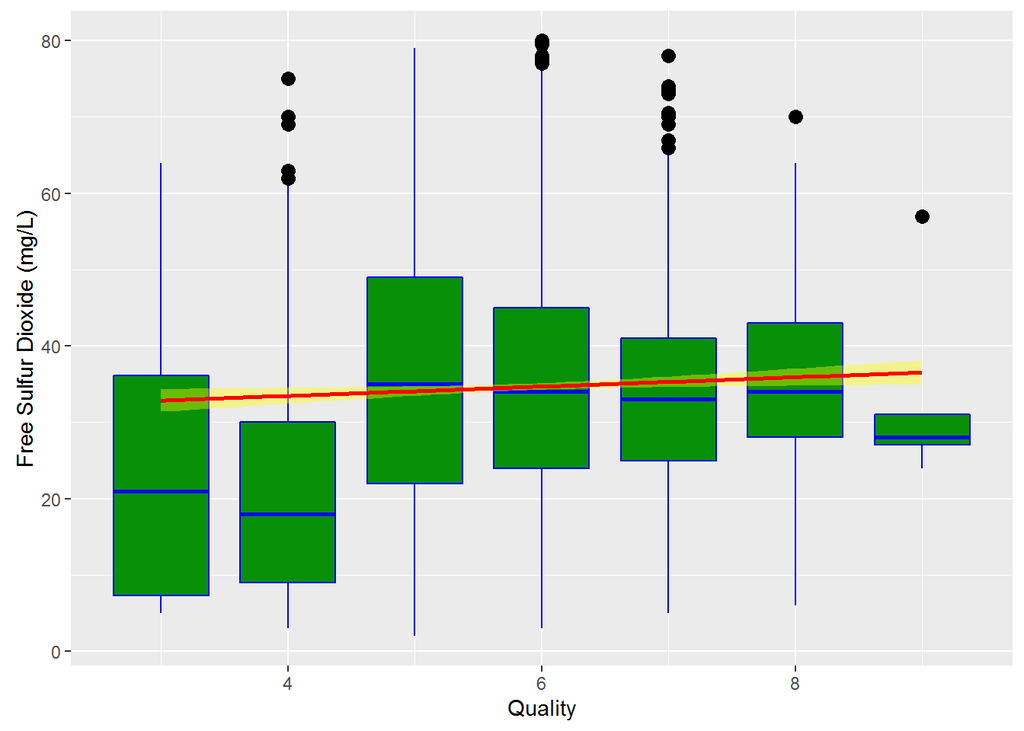

The line modeling shows no clear relation between Free Sulfur Dioxide and Quality. We can say that it is very hard to see that Free Sulfur Dioxide in wines correlates with Quality.

Next, I need to study whether the total.sulfur.dioxide affects the quality of wine.

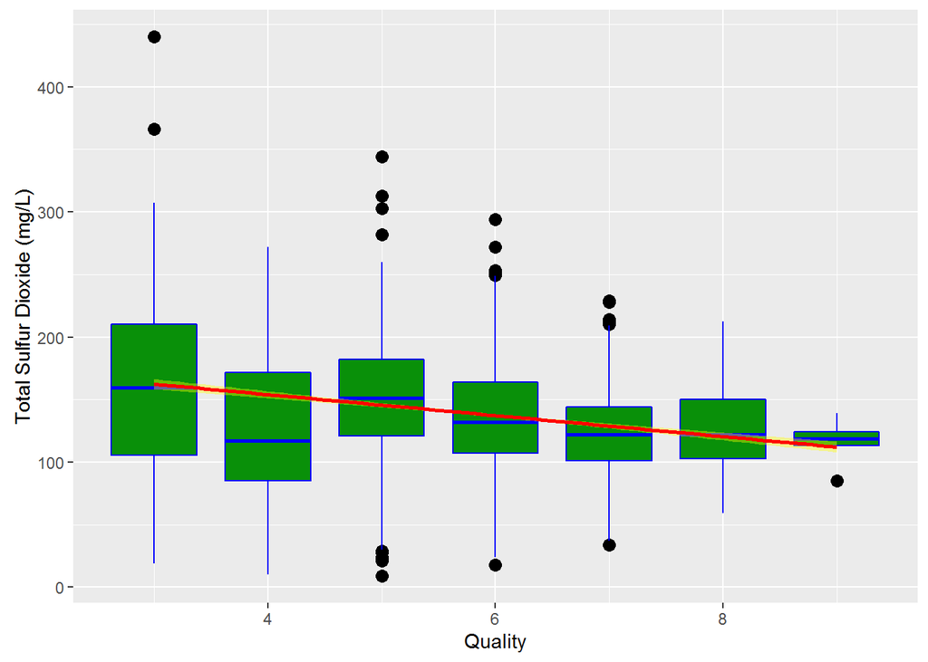

I am afraid that the outliers of Total Sulfur Dioxide are affecting the accuracy. I need to remove these outliers.

Redraw the plot.

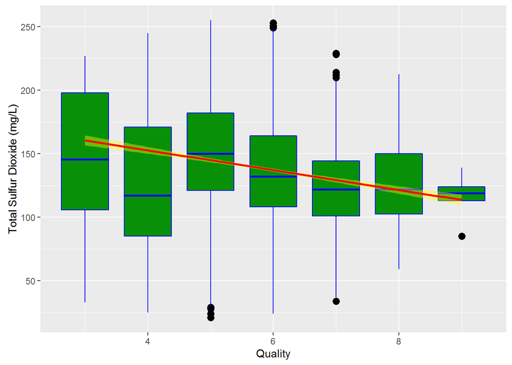

We can see that wines with higher Total Sulfur Dioxide tend to have low quality. To further study this, I am going to create the Density distribution plot.

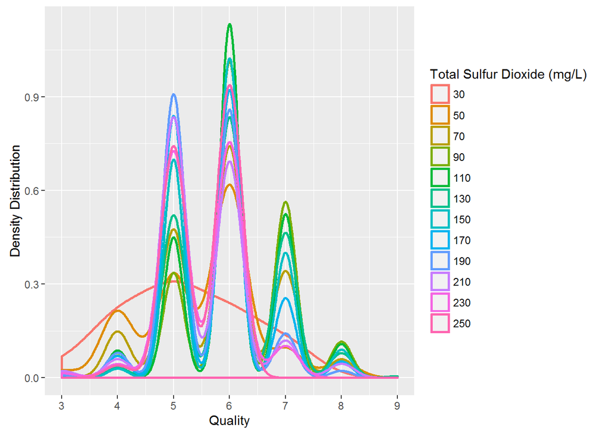

In this plot, when Quality is 7 and 8, Density distribution curves with Total Sulfur Dioxide from 70mg/L to 170mg/L have higher values than other Total Sulfur Dioxide values. So we can say that wines with high Quality tend to have the level of Total Sulfur Dioxide at around 70mg/L to 170mg/L. Too much or too less Total Sulfur Dioxide is affecting the Quality of wines negatively.